# 乡村音乐词曲作者生态：榜单长尾与歌词词频

TidyTuesday · 2026-08-25 · 484 首乡村电台 Top 30 歌曲的作者、制作人与歌词

作者

zlZayn

发布于

2026年9月20日

# 写歌的人多，还是做歌的人多

`country_lyrics.csv` 收录 **484 首**进入乡村电台 Top 30 的歌曲（2013–2019），涉及 121 位歌手。同名歌只有一组：Every Little Thing（Carly Pearce, 2017） / Every Little Thing（Russell Dickerson, 2019） —— 不同歌手、不同年份，是两首作品，不是重复行；483 个歌名唯一。

榜单文件给出三类角色：**510 位词曲作者**、**71 行”主创作者”**、**110 位制作人**。两个问题：写歌的人比做歌的人多多少，头部集中度是不是同一种形状？七年里歌词最常出现的词换了没有？

## 先把三份榜单的口径钉死

表 1: 表 1 · 四个输入文件的口径与处置

| 文件 | 规模 | 计数取值 | 本轮处置 |
| --- | --- | --- | --- |
| country_lyrics.csv | 484 行 × 8 列 | — | 行 = 一首歌；rough_order 1–484 唯一且按年份递增，用作行 ID |
| top_all_writers.csv | 510 行 × 2 列 | 0–44 | 剔除 8 行 song_count = 0（双对数无法取对数），其余全部入图 |
| top_primary_writers.csv | 71 行 × 2 列 | 5–44 | 先按同名取最大计数折叠 12 行重名 → 59 位；文件本身不是降序 |
| top_producers.csv | 110 行 × 2 列 | 1–59 | 无 0 值、无重名、已降序，直接入图 |

**榜单文件不是歌词的精确重算**，这是本周最需要先说清的一条：

表 2: 表 2 · 榜单文件 vs 歌词字段重算（重算口径：writers 按逗号切分后逐首计数）

| 对账项 | 全体词曲作者 | 制作人 |
| --- | --- | --- |
| 计数一致的行 | 468 / 510 | 97 / 110 |
| 计数不一致的行 | 42 | 13 |
| 最大差额 | 6 首 | 2 首 |
| 文件偏高 / 文件偏低 | 10 / 32 | 2 / 11 |
| 只出现在歌词侧的名字 | 7 个 | 62 个 |
| 文件计 0 却在歌词里出现 | 8 个 | 0 个 |

三个必须记住的细节：

1. **`top_all_writers.csv` 有 8 行 `song_count = 0`**，而这 8 个名字在歌词 `writers` 字段里都出现过、重算各 1 首（Keifer Thompson、Shawna Thompson、Westin Davis……）。0 在双对数上无定义，图 1 把它们剔除并写明差额，不静默丢。
2. **`top_primary_writers.csv` 有 12 行重名**（Nicolle Galyon 出现两次，计数 12 与 12），而且文件没有按计数降序。折叠成 59 位后，其中 **58 位同时出现在全量作者榜里，且 58 位计数完全相同** —— “主创作者”不是另一套统计，而是同一份统计切出来的一段；唯一不在全量榜里的是 Chris Dubois。
3. **制作人榜只覆盖重算结果的一部分**：从歌词切分可得 172 位制作人，文件收录 110 位，其中 62 位只在歌词里出现；两边计数差最大 2 首。

作者名还有拼写与别名两套写法，直接决定”重算 vs 榜单”能不能对上：

表 3: 表 3 · 同一个人的两套写法（大小写、别名、错拼各举其例）

| 歌词侧写法 | 榜单侧写法 |
| --- | --- |
| Scotty Mccreery | Scotty McCreery |
| Jessie Jo Dillon | Jessie Jo DIllon |
| HARDY | Michael Hardy |
| Chris Dubois | Chris DuBois |
| Weston Davis | Westin Davis |
| Bretty Young | Brett Young |

## 图 1：三条秩–规模曲线

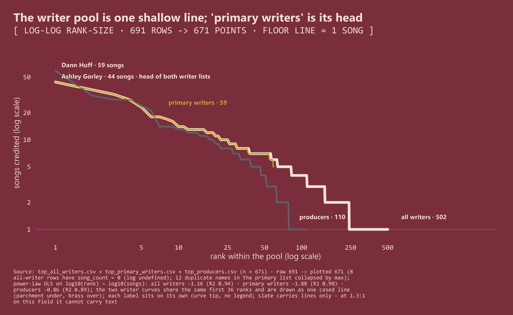

图 1: Three leaderboards on one log-log plane: writers and producers are both heavy-headed power-law lines, and the ‘primary writers’ slice hugs the writer line before the two part.

**读数**（都取自上图的同一份聚合）：

- 三条曲线在双对数上都接近直线，幂律斜率分别是 -1.16（R² 0.94）、-1.88（0.98）、-0.86（0.89）。
- 头部：制作人榜第一名 Dann Huff 59 首，比任何一位词曲作者都多；作者榜第一名 Ashley Gorley 44 首，占 484 首歌的 9.1%。两条写作者曲线共用这个起点。
- 尾巴：全量榜里 **259 位作者只写了 1 首**（51%），制作人榜里 1 首的有 32 位（29%）。
- **“主创作者”不是第二种分布**：它和全量作者榜的前 36 名逐位相同（同计数、同顺序），之后才分叉，所以看起来更陡（斜率 -1.88 对 -1.16）。能作为”两个生态”比较的是写作者与制作人两条完整曲线，不是这三条并列。

## 图 2：歌词词频的两个年代

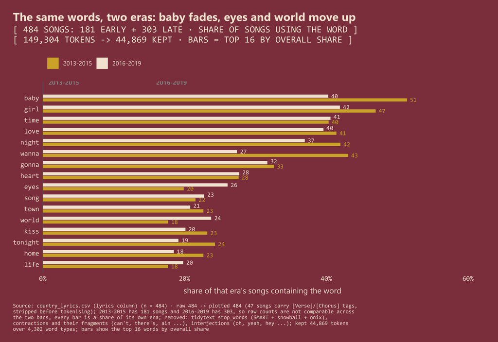

图 2: Lyric vocabulary across two eras: the same handful of words dominates both halves, but the later half leans on body and world words where the earlier half leaned on baby, girl and night.

**读数**：

- 两个年代的样本量不同（181 vs 303 首），所以条形是”该年代里用到这个词的歌曲占比”，不是原始次数；正文与表 4 用的是同一份占比表。
- 全场最高频的词是 **baby**：2013–2015 有 51% 的歌曲用到，2016–2019 降到 40%。
- 就在图上这 16 个词里，掉得最狠的三个是 wanna -16、baby -11、tonight -5；涨得最多的是 eyes +6、world +6、life +2（单位：百分点）。
- 骨架没动：图上 16 个词里最稳的两个是 heart 与 time，差只有 +0.1 与 +0.3 个百分点（其余 14 个都在动）。

表 4: 表 4 · 图 2 的同一份聚合（占比 = 用过该词的歌曲 / 该年代歌曲数；末列 = 全部 484 首里用到该词的歌曲数）

| 词 | 2013-2015 | 2016-2019 | 全部 484 首 | 差（百分点） | 出现于几首 |
| --- | --- | --- | --- | --- | --- |
| baby | 51% | 40% | 44% | -11 | 215 |
| girl | 47% | 42% | 44% | -5 | 212 |
| time | 40% | 41% | 40% | +0 | 196 |
| love | 41% | 40% | 40% | -2 | 195 |
| night | 42% | 37% | 39% | -5 | 188 |
| wanna | 43% | 27% | 33% | -16 | 161 |
| gonna | 33% | 32% | 32% | -1 | 155 |
| heart | 28% | 28% | 28% | +0 | 134 |
| eyes | 20% | 26% | 24% | +6 | 115 |
| song | 22% | 23% | 22% | +1 | 108 |
| town | 23% | 21% | 21% | -2 | 104 |
| world | 18% | 24% | 21% | +6 | 104 |
| kiss | 23% | 20% | 21% | -3 | 103 |
| tonight | 24% | 19% | 21% | -5 | 102 |
| home | 23% | 18% | 20% | -4 | 97 |
| life | 18% | 20% | 19% | +2 | 92 |

## 图 3：把 16 个高频词之外的变化也读出来

图 2 只能显示 16 个词，而”占比差”受两个年代样本量不等的影响。图 3 换一个口径：只保留在全部 484 首里至少用过 25 首的词，算**加一平滑的对数几率（log-odds）**——后期用到这个词的几率相对前期的倍数。条形向左 = 更偏 2013–2015，向右 = 更偏 2016–2019。

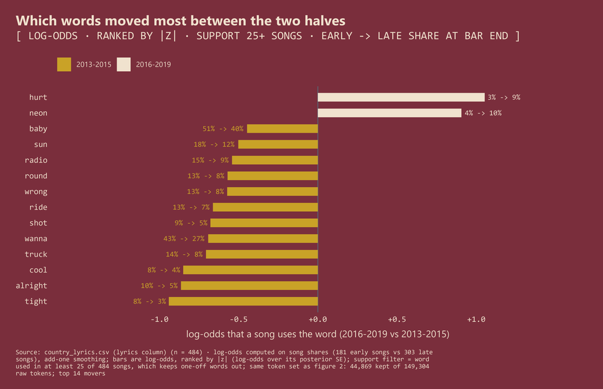

**读数**：14 个变动最大的词里，只有 2 个偏向 2016–2019（hurt（3% → 9%，+1.05）、neon（4% → 10%，+0.91）），12 个偏向 2013–2015，最偏的几个是 tight（8% → 3%，-0.94）、alright（10% → 5%，-0.86）、cool（8% → 4%，-0.85）。括号里是”早期占比 → 后期占比”与该词的对数几率。注意这与”最常出现的词”是两回事：baby 仍然两边都最常见，只是它更偏早期。

## 同一批歌里的第三个变化：署名人数在涨

表 5: 表 5 · 每首歌的署名作者数与制作人数（2013 只有 13 首，读趋势请从 2014 起）

| 入榜年份 | 歌曲数 | 平均署名作者 | 署名 4 位以上的占比 | 平均制作人 |
| --- | --- | --- | --- | --- |
| 2013 | 13 | 2.92 | 15.4% | 1.69 |
| 2014 | 89 | 2.89 | 16.9% | 1.45 |
| 2015 | 79 | 3.06 | 19.0% | 1.49 |
| 2016 | 79 | 3.05 | 15.2% | 1.51 |
| 2017 | 76 | 3.00 | 21.1% | 1.73 |
| 2018 | 80 | 3.21 | 26.2% | 1.57 |
| 2019 | 68 | 3.41 | 35.3% | 1.57 |

- 484 首歌一共 1,495 个作者署名（去重后 517 位），平均每首 3.09 位；署名 4 位以上的歌占 21.7%。
- 平均署名人数从 2014 年的 2.89 位涨到 2019 年的 3.41 位；署名 4 位以上的占比同期从 16.9% 涨到 35.3%。
- 独署（只有 1 位作者）的歌 10 首：Drink A Beer（Luke Bryan, 2013）；Stay（Florida Georgia Line, 2014）；Gentle On My Mind（The Band Perry, 2014）；Humble And Kind（Tim McGraw, 2016）；Better Man（Little Big Town, 2016）；We Should Be Friends（Miranda Lambert, 2017）；Outta Style（Aaron Watson, 2017）；Ask Me How I Know（Garth Brooks, 2017）；Greatest Love Story（LANCO, 2017）；Millionaire（Chris Stapleton, 2018）。署名最多的是 Vacation（Thomas Rhett, 2016, 14 位作者）——它采样了别人的作品，所以把原曲作者一并列上。
- 44% 的歌有两位以上制作人；制作人署名比作者署名短得多。

## 方法与口径

[output not shown]